# ps05_md_basicplots

Candice

2023-02-17

# 1.Load and check data (5pt)

```r
g <- read.delim("gapminder.csv")
dim(g)
```

```
## [1] 13055    25
```

```r
sample_n(g,5)
```

```
##   iso3                               name iso2   region
## 1  CZE                            Czechia   CZ   Europe
## 2  ISR                             Israel   IL     Asia
## 3  GEO                            Georgia   GE     Asia
## 4  VEN Venezuela (Bolivarian Republic of)   VE Americas
## 5  NLD                        Netherlands   NL   Europe
##                        sub.region intermediate.region time totalPopulation
## 1                  Eastern Europe                     1974         9988459
## 2                    Western Asia                     1964         2475000
## 3                    Western Asia                     2009         3814419
## 4 Latin America and the Caribbean       South America 2002        25100408
## 5                  Western Europe                     1974        13545056
##   fertilityRate lifeExpectancy childMortality youthFemaleLiteracy
## 1         2.460       70.08659             NA                  NA
## 2         3.826             NA           33.6                  NA
```

[output cut: 21 more lines]

# 2.Descriptive statistics (15pt)

## 1.

```r
length(unique(g$iso3))
```

```
## [1] 253
```

```r
length(unique(g$name))
```

```
## [1] 250
```

```r
length(unique(g$iso2))
```

```
## [1] 249
```

## 2.

### (a).

```r
g %>%
  group_by(iso2) %>%
  summarise(n = n_distinct(name))
```

```
## # A tibble: 249 × 2
##    iso2      n
##    <chr> <int>
##  1 ""        2
##  2 "AD"      1
##  3 "AE"      1
##  4 "AF"      1
##  5 "AG"      1
##  6 "AI"      1
##  7 "AL"      1
##  8 "AM"      1
##  9 "AO"      1
## 10 "AQ"      1
## # … with 239 more rows
```

```r
unique(g$name[g$iso2 == ""])
```

```
## [1] ""        "Namibia"
```

### (b).

```r
g %>%
  group_by(name) %>%
  summarise(n1 = n_distinct(iso3))
```

```
## # A tibble: 250 × 2
##    name                     n1
##    <chr>                 <int>
##  1 ""                        4
##  2 "Afghanistan"             1
##  3 "Albania"                 1
##  4 "Algeria"                 1
##  5 "American Samoa"          1
##  6 "Andorra"                 1
##  7 "Angola"                  1
##  8 "Anguilla"                1
##  9 "Antarctica"              1
## 10 "Antigua and Barbuda"     1
## # … with 240 more rows
```

```r
unique(g$iso3[g$name == ""])
```

```
## [1] "CHANISL"     "GBM"         "KOS"         "NLD_CURACAO"
```

## 3.

```r
g %>%
  select(time) %>%
  filter(!is.na(time)) %>%
  min()
```

```
## [1] 1960
```

```r
g %>%
  select(time) %>%
  filter(!is.na(time)) %>%
  max()
```

```
## [1] 2019
```

# 3.CO2 emissions (30pt)

## 1.

```r
a <- g %>%
  group_by(time) %>%
  filter(!is.na(time)) %>%
  summarise(n1 = length(is.na(co2)), n2 = length(is.na(co2_PC)), total = n1 +n2)

a
```

```
## # A tibble: 60 × 4
##     time    n1    n2 total
##    <int> <int> <int> <int>
##  1  1960   216   216   432
##  2  1961   217   217   434
##  3  1962   217   217   434
##  4  1963   217   217   434
##  5  1964   217   217   434
##  6  1965   217   217   434
##  7  1966   217   217   434
##  8  1967   217   217   434
##  9  1968   217   217   434
## 10  1969   217   217   434
## # … with 50 more rows
```

#### years with most missing data:

```r
a$time[a$total == max(a$total)]
```

```
##  [1] 1961 1962 1963 1964 1965 1966 1967 1968 1969 1970 1971 1972 1973 1974 1975
## [16] 1976 1977 1978 1979 1980 1981 1982 1983 1984 1985 1986 1987 1988 1989 1990
## [31] 1991 1992 1993 1994 1995 1996 1997 1998 1999 2000 2001 2002 2003 2004 2005
## [46] 2006 2007 2008 2009 2010 2011 2012 2013 2014 2015 2016 2017 2018 2019
```

## 2.

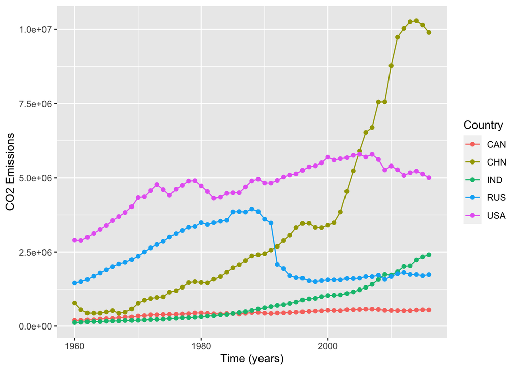

```r
g %>%
  filter(!is.na(co2)) %>%
  filter(iso3 == "USA" | iso3 == "CHN" |
           iso3 == "IND" | iso3 == "CAN" | iso3 == "RUS") %>%
ggplot(aes(time, co2, col=factor(iso3))) +
  geom_line() +
  geom_point() +
  labs(x = "Time (years)", y = "CO2 Emissions",
       col = "Country")
```

#### This chart tells me that Canada’s CO2 emissions are the most stable, much fewer than others’; both Russia and China have fallen after some growth, but China’s emissions are still at a high level; India’s emissions are steadily rising; and the U.S. emissions are less stable overall, but also show some growth followed by a decline.

## 3.

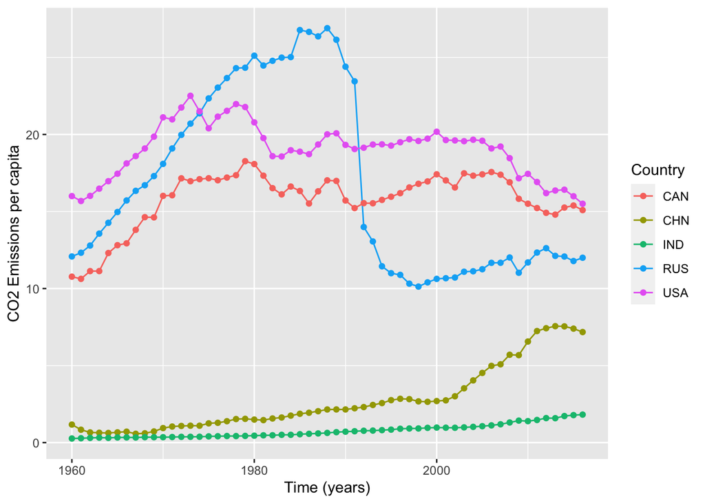

```r
g %>%
  filter(!is.na(co2_PC)) %>%
  filter(iso3 == "USA" | iso3 == "CHN" |
           iso3 == "IND" | iso3 == "CAN" | iso3 == "RUS") %>%
ggplot(aes(time, co2_PC, col=factor(iso3))) +
  geom_line() +
  geom_point() +
  labs(x = "Time (years)", y = "CO2 Emissions per capita",
       col = "Country")
```

#### This chart tells me that India’s per capita CO2 emissions are very stable and consistently lower than the other four countries; Canada, the U.S., and Russia’s per capita carbon emissions all start out with very significant increases and then flow back down, with Russia falling back the most, similar emission level as the 1960s; and China’s per capita carbon emissions increase later than those three countries and also are much lower than theirs.

## 4.

```r
g %>%
  filter(!is.na(co2_PC)) %>%
  group_by(time, region) %>%
  summarise(n = mean(co2_PC))
```

```
## # A tibble: 294 × 3
## # Groups:   time [57]
##     time region       n
##    <int> <chr>    <dbl>
##  1  1960 Africa   0.291
##  2  1960 Americas 7.15
##  3  1960 Asia     1.74
##  4  1960 Europe   5.77
##  5  1960 Oceania  2.73
##  6  1961 Africa   0.300
##  7  1961 Americas 7.38
##  8  1961 Asia     2.06
##  9  1961 Europe   5.92
## 10  1961 Oceania  2.85
## # … with 284 more rows
```

#### From here I can see that overall per capita CO2 emissions have increased from 1960 to 2016 on all continents except the Americas; Asia has increased the most and Africa the least; in 1960 the most was in the Americas and the least was in Africa; in 2016 the most was in Europe and the least was still in Africa.

## 5.

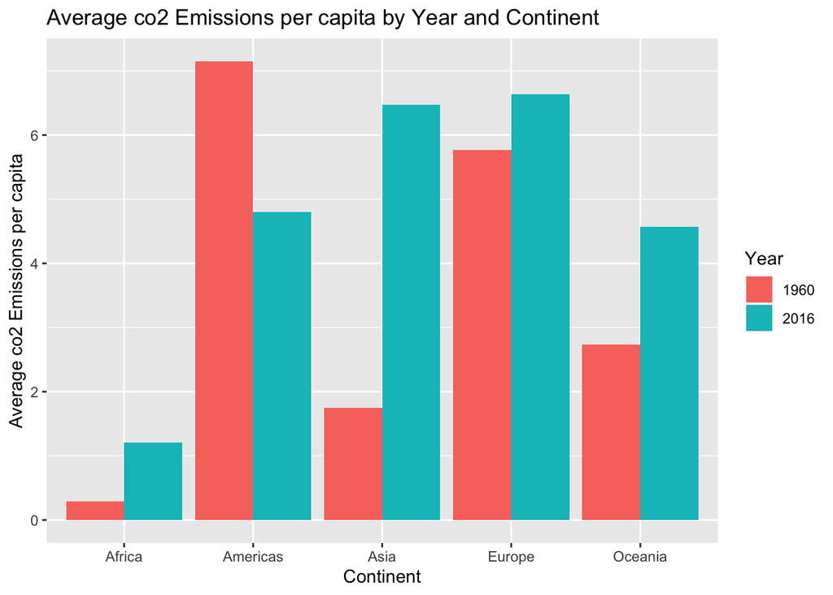

```r
g %>%
  filter(time == 1960 | time == 2016, !is.na(co2_PC), !is.na(region) ) %>%
  filter(region != "") %>%
  group_by(time, region) %>%
  summarise(avg_co2pc = mean(co2_PC), .groups = "drop") %>%

ggplot(aes(x = region, y = avg_co2pc, fill=as.factor(time))) +
  geom_col(position = "dodge") +
  labs(title = "Average co2 Emissions per capita by Year and Continent",
       x = "Continent", y = "Average co2 Emissions per capita") +
  scale_fill_discrete(name = "Year")
```

## 6.

#### Because 2019 data is missing, I’ll take 2016.

```r
g %>%
  filter(!is.na(co2_PC), region != "") %>%
  filter(time == "2016") %>%
  group_by(region, name) %>%
  summarize(avg_co2_pc = co2_PC, .groups = "drop") %>%
  arrange(region, avg_co2_pc) %>%
  select(region, name, avg_co2_pc) %>%
  group_by(region) %>%
  filter(rank(avg_co2_pc) <4 | rank(desc(avg_co2_pc)) <4)
```

```
## # A tibble: 30 × 3
## # Groups:   region [5]
##    region   name                              avg_co2_pc
##    <chr>    <chr>                                  <dbl>
##  1 Africa   Congo, Democratic Republic of the     0.0256
##  2 Africa   Somalia                               0.0455
##  3 Africa   Burundi                               0.0472
##  4 Africa   Seychelles                            6.39
##  5 Africa   Libya                                 7.79
##  6 Africa   South Africa                          8.48
##  7 Americas Haiti                                 0.275
##  8 Americas Nicaragua                             0.887
##  9 Americas Honduras                              1.06
## 10 Americas Canada                               15.1
## # … with 20 more rows
```

# 4.GDP per capita (50pt)

## 1.

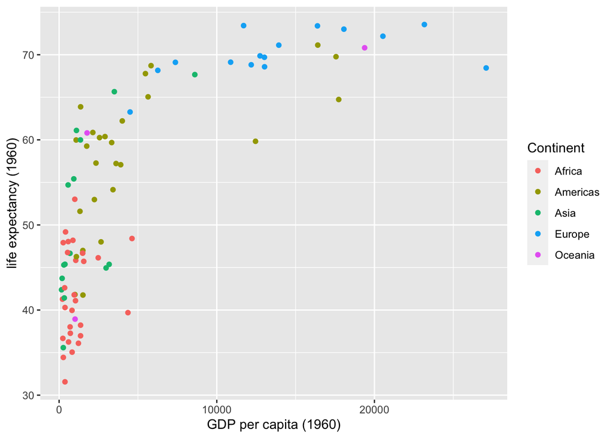

```r
g %>%
  filter(time == 1960) %>%
  filter(!is.na(GDP_PC), !is.na(lifeExpectancy)) %>%
ggplot(aes(GDP_PC, lifeExpectancy, col=factor(region))) +
  geom_point() +
  labs(x = "GDP per capita (1960)", y = "life expectancy (1960)",
       col = "Continent")
```

#### In this graph, we can see that in 1960, Europe had the longest GDP per capita and life expectancy; while Africa had both lower; it can be seen that GDP per capita and life expectancy show a certain positive relationship.

## 2.

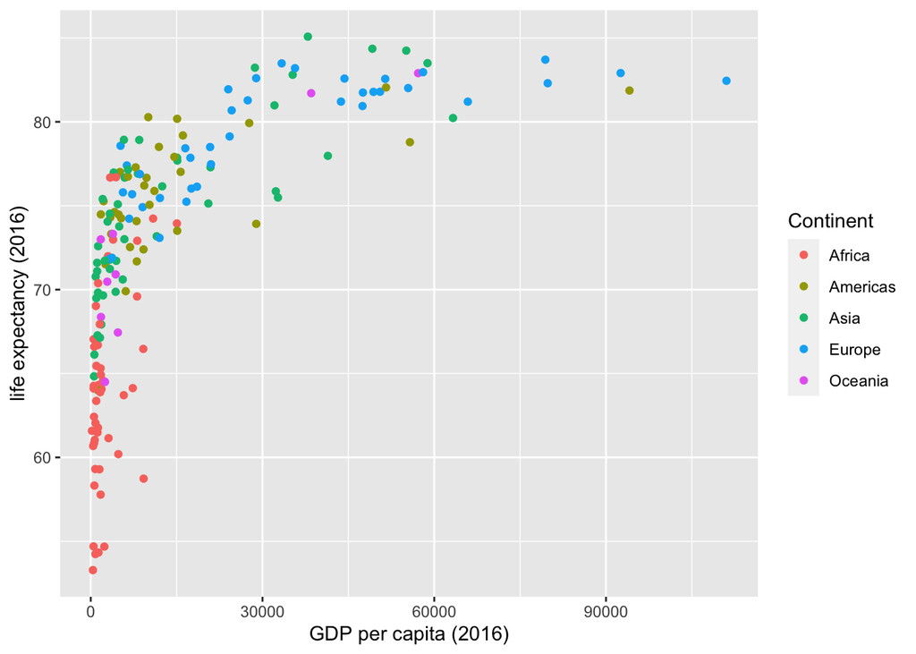

```r
g %>%
  filter(time == 2019) %>%
  filter(!is.na(GDP_PC), !is.na(lifeExpectancy), !is.na(region), region != "") %>%
ggplot(aes(GDP_PC, lifeExpectancy, col=factor(region))) +
  geom_point() +
  labs(x = "GDP per capita (2016)", y = "life expectancy (2016)",
       col = "Continent")
```

## 3.

#### GDP per capita has grown substantially, from a predominant distribution of 0 to 20,000 in 1960 to 0 to 90,000 in 2019; people are living relatively longer; what’s similar is that Europe still has the highest GDP per capita and life expectancy, and Africa is still relatively low. Overall, the world has developed a lot over the past six decades.

## 4.

```r
g %>%
  filter(!is.na(lifeExpectancy), region != "") %>%
  group_by(region, time) %>%
  filter(time == 1960 | time == 2019) %>%
  summarise(n = mean(lifeExpectancy))
```

```
## # A tibble: 10 × 3
## # Groups:   region [5]
##    region    time     n
##    <chr>    <int> <dbl>
##  1 Africa    1960  41.5
##  2 Africa    2019  64.1
##  3 Americas  1960  58.6
##  4 Americas  2019  75.8
##  5 Asia      1960  51.6
##  6 Asia      2019  74.6
##  7 Europe    1960  68.3
##  8 Europe    2019  79.4
##  9 Oceania   1960  56.4
## 10 Oceania   2019  73.5
```

#### Yes, it fit with what I see on the figures.

## 5.

#### This question is a little confusing. I did a few answers for different understanding.

#### (1)

#### In discord, I saw someone said, “I checked with a TA and she said to only use data from 1960 and 2019, and I grouped by region and time. So u can filter for time == 1960 and 2019”.

#### In this case, for this one, I compute the average LE in 1960 and 2019 across the continents. Since there is no data before 1960, the growth in 1960 is just NA.

#### Here, the “growth” means the total growth from 1960 to 2019, not every year.

```r
m <- g %>%
  filter(time == 1960 | time == 2019) %>%
  filter(!is.na(region), !is.na(lifeExpectancy), region != "") %>%
  group_by(region, time) %>%
  summarise(avgLE = mean(lifeExpectancy), .groups = "drop") %>%
  group_by(region) %>%
  mutate(prev = lag(avgLE), growth = avgLE - prev ) %>%
  arrange(growth)
m
```

```
## # A tibble: 10 × 5
## # Groups:   region [5]
##    region    time avgLE  prev growth
##    <chr>    <int> <dbl> <dbl>  <dbl>
##  1 Europe    2019  79.4  68.3   11.1
##  2 Oceania   2019  73.5  56.4   17.1
##  3 Americas  2019  75.8  58.6   17.2
##  4 Africa    2019  64.1  41.5   22.6
##  5 Asia      2019  74.6  51.6   23.0
##  6 Africa    1960  41.5  NA     NA
##  7 Americas  1960  58.6  NA     NA
##  8 Asia      1960  51.6  NA     NA
##  9 Europe    1960  68.3  NA     NA
## 10 Oceania   1960  56.4  NA     NA
```

#### (2)

#### This one is the growth of average LE each year from 1960-2019, showed by the order of the growth.

```r
l <- g %>%
  filter(!is.na(region), !is.na(lifeExpectancy), region != "") %>%
  group_by(region, time) %>%
  summarise(avgLE = mean(lifeExpectancy), .groups = "drop") %>%
  group_by(region) %>%
  mutate(prev = lag(avgLE), growth = avgLE - prev ) %>%
  filter(!is.na(prev)) %>%
  group_by(region) %>%
  arrange(growth)
l
```

```
## # A tibble: 295 × 5
## # Groups:   region [5]
##    region   time avgLE  prev   growth
##    <chr>   <int> <dbl> <dbl>    <dbl>
##  1 Oceania  1988  66.6  66.8 -0.189
##  2 Europe   1993  73.5  73.6 -0.101
##  3 Africa   1993  53.7  53.7 -0.0615
##  4 Oceania  1996  68.5  68.5 -0.0560
##  5 Europe   2015  78.8  78.8 -0.0308
##  6 Africa   1992  53.7  53.8 -0.0301
##  7 Europe   1991  73.5  73.5 -0.0146
##  8 Europe   1990  73.5  73.5 -0.0100
##  9 Europe   1969  70.0  70.0 -0.00233
## 10 Africa   1990  53.7  53.7  0.00651
## # … with 285 more rows
```

#### (3)

#### This one is the average annual LE growth through 1960-2019.

```r
i <- l %>%
  select(region, growth) %>%
  group_by(region) %>%
  summarise(avgGrowth = sum(growth)/(2019-1960)) %>%
  arrange(avgGrowth)

i
```

```
## # A tibble: 5 × 2
##   region   avgGrowth
##   <chr>        <dbl>
## 1 Europe       0.188
## 2 Oceania      0.290
## 3 Americas     0.291
## 4 Africa       0.384
## 5 Asia         0.389
```

#### I hope there’s something here that you want.

#### In conclusion, we can see that the total increase in life expectancy is the highest in Asia and the lowest in Europe, same as what the average anuual one shows; also, to some extent, the increase might be easier when life expectancy is lower.

## 6.

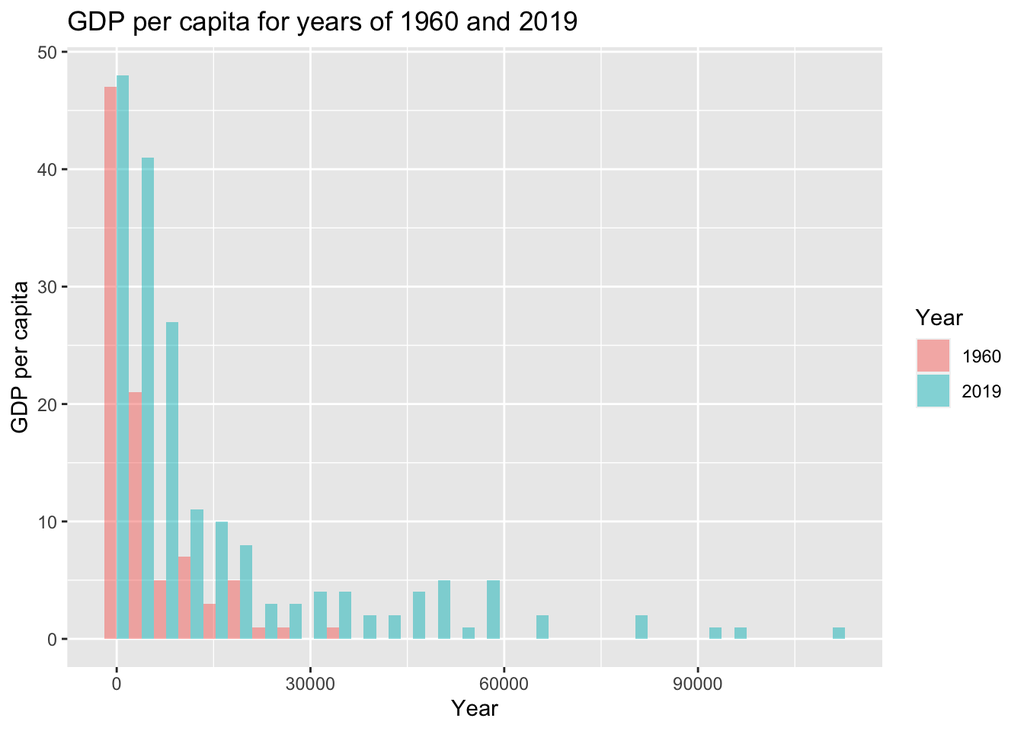

```r
g %>%
  filter(time == 1960 | time == 2019, !is.na(GDP_PC)) %>%
  ggplot(aes(x = GDP_PC, fill=factor(time))) +
  geom_histogram(alpha = 0.5, position = "dodge", bins = 30) +
  labs(title = "GDP per capita for years of 1960 and 2019",
       x = "Year", y = "GDP per capita") +
  scale_fill_discrete(name = "Year")
```

## 7.

```r
g %>%
  select(name, time, lifeExpectancy) %>%
  filter(name !="", !is.na(time), !is.na(lifeExpectancy)) %>%
  filter(time == 1960) %>%
  mutate(rank = rank(desc(lifeExpectancy))) %>%
  filter(name == "United States of America")
```

```
##                       name time lifeExpectancy rank
## 1 United States of America 1960       69.77073   17
```

```r
g %>%
  select(name, time, lifeExpectancy) %>%
  filter(name !="", !is.na(time), !is.na(lifeExpectancy)) %>%
  filter(time == 2019) %>%
  mutate(rank = rank(desc(lifeExpectancy))) %>%
  filter(name == "United States of America")
```

```
##                       name time lifeExpectancy rank
## 1 United States of America 2019        78.7878   46
```

## 8.

```r
g %>%
  select(name, time, lifeExpectancy) %>%
  filter(name !="", !is.na(time), !is.na(lifeExpectancy)) %>%
  group_by(time) %>%
  mutate(rank = rank(desc(lifeExpectancy)), num = length(name)) %>%
  filter(name == "United States of America") %>%
  mutate(r = rank/num) %>%
  select(time, r)
```

```
## # A tibble: 60 × 2
## # Groups:   time [60]
##     time      r
##    <int>  <dbl>
##  1  1960 0.0904
##  2  1961 0.0741
##  3  1962 0.0899
##  4  1963 0.106
##  5  1964 0.117
##  6  1965 0.111
##  7  1966 0.138
##  8  1967 0.111
##  9  1968 0.169
## 10  1969 0.132
## # … with 50 more rows
```

## I spent about 8 hours on this PS.